# Take-home Exercise 2:

- Show All Code
- Hide All Code
- View Source

VAST Challenge 2026 - Mini-Challenge 1

Published

June 1, 2026

Modified

June 7, 2026

# 1 Overview

This report answers [VAST Challenge 2026 Mini-Challenge 1](https://vast-challenge.github.io/2026/MC1.html). All main graphs are interactive: hover over points, tiles, nodes or bars to view tooltips with the underlying details.

## 1.1 The scenario

**TenantThread** is being acquired by **CivicLoom Realty Partners** under an embargo until **6:00 PM on 2046-06-05**. Seven AI agents manage communications, with a compliance agent (*“The Judge”*) assigned to enforce the rules. Despite that guardrail, merger details appeared on agent-linked social accounts **around 5:00 PM**, roughly one hour early.

## 1.2 The questions

> 1. What were the key events and relationships that led up to the inappropriate release? Visualise the sequence of events (key actions, causal relationships, decision points and actors), and highlight what let the post past embargo enforcement.
> 2. The evasion of the embargo was a *new* behaviour. Discover and illustrate the *typical* behaviour of the agents, and compare it to the behaviour that led to the release.
> 3. Were there *leading indicators* that such a release was possible? Did agents’ actual behaviour ever differ from their *expected* behaviour, and why did earlier occasions draw no action?

## 1.3 Methodology

**NoteApproach**

I flatten the nested JSON into message- and round-level tables, then combine timelines, channel and network views, baseline comparisons, and anomaly framing to explain how the embargo breach unfolded.

# 2 Setup

## 2.1 Loading packages

The analysis uses `tidyverse` for wrangling and `ggplot2`/`ggiraph` for static and interactive figures.

- [tidyverse](https://www.tidyverse.org/) - `dplyr`, `tidyr`, `purrr`, `stringr`, `forcats`, `lubridate`, `ggplot2` for the full data-science workflow
- jsonlite - to parse the nested MC1 JSON
- [scales](https://scales.r-lib.org/) - axis formatting (dollars, percents)
- [ggtext](https://wilkelab.org/ggtext/) - rich-text titles/subtitles for visual storytelling
- [ggiraph](https://davidgohel.github.io/ggiraph/) - **interactive** ggplots (hover tooltips)
- [knitr](https://yihui.org/knitr/) - `kable()` tables

```r
pacman::p_load(tidyverse, jsonlite, scales, ggtext, ggiraph, knitr)
dir.create("figures", showWarnings = FALSE)
```

## 2.2 Loading the data

The challenge provides one nested JSON file, `MC1_final_00.json`. I read it without simplification so the nested fields remain explicit.

```r
raw <- fromJSON("VAST_Challenge_2026_MC1/MC1_final_00.json", simplifyVector = FALSE)
rounds_raw <- raw$rounds
length(rounds_raw)            # number of rounds
```

```
[1] 23
```

```r
names(rounds_raw[[1]])        # the fields inside one round
```

```
[1] "hour"                "environment_context" "communications"
[4] "participants"
```

## 2.3 Common aesthetics

Shared palettes, factor orders and theme settings keep the figures consistent. The main palette is the colour-blind-safe **Okabe–Ito** set.

```r
OI <- c(blue="#0072B2", orange="#E69F00", green="#009E73", red="#D55E00",
        purple="#CC79A7", sky="#56B4E9", yellow="#F0E442", grey="#999999")

chan_levels <- c("comms_huddle","one_on_one_chat","side_huddle",
                 "official_post","personal_post","anonymous_post")
chan_cols <- c("#56B4E9","#0072B2","#CC79A7","#009E73","#E69F00","#D55E00")
names(chan_cols) <- chan_levels

# 3-class channel grouping for Fig 2 - the story is internal → unofficial-public,
# so we collapse the six raw channels into three meaningful classes.
chan_class <- function(ch) dplyr::case_when(
  ch %in% c("comms_huddle","one_on_one_chat","side_huddle") ~ "Internal",
  ch == "official_post"                                     ~ "Official",
  ch %in% c("personal_post","anonymous_post")               ~ "Unofficial-public",
  TRUE ~ NA_character_)
class_lv  <- c("Internal","Official","Unofficial-public")
class_col <- c(Internal="#56B4E9", Official="#009E73", `Unofficial-public`="#D55E00")

# Harmonized sentiment scale - the raw data uses two label schemes (lowercase pre-crisis,
# UPPERCASE crisis-day) that produced 7 levels with duplicate colours. We collapse them to
# one ordered calm→crisis→recovery ramp with distinct, colour-blind-safe hues.
sent_recode <- c(neutral="Neutral", cautious="Cautious",
                 negative="Negative / Low", LOW="Negative / Low",
                 critical="Critical", CRITICAL="Critical",
                 RECOVERING="Recovering")
sent5_lv  <- c("Neutral","Cautious","Negative / Low","Critical","Recovering")
sent5_col <- c(Neutral="#BDBDBD", Cautious="#F0E442", `Negative / Low`="#E69F00",
               Critical="#9E2A00", Recovering="#009E73")

agent_levels <- c("legal_agent","quality_agent","pr_agent","social_media_agent",
                  "judge_agent","pr_intern_agent","intern_agent")
agent_short <- c(legal_agent="Legal*", quality_agent="Platform-Trust*",
                 pr_agent="PR*", social_media_agent="Social-Mgr*",
                 judge_agent="Judge (compliance)", pr_intern_agent="PR-Intern",
                 intern_agent="Intern")   # * = senior agent

mc1_theme <- function() {
  theme_minimal(base_size = 12) +
    theme(plot.title    = element_textbox_simple(face="bold", size=15, margin=margin(b=4)),
          plot.subtitle = element_textbox_simple(size=11, colour="grey30", margin=margin(b=10)),
          plot.caption  = element_text(size=8.5, colour="grey45", hjust=0),
          panel.grid.minor = element_blank(),
          legend.position  = "top")
}
theme_set(mc1_theme())

# Render an interactive ggiraph widget from a ggplot containing *_interactive geoms.
show_girafe <- function(p, h = 5.6) {
  girafe(ggobj = p, width_svg = 11, height_svg = h,
         options = list(
           opts_tooltip(css = "background:#222;color:#fff;padding:6px 8px;border-radius:4px;font-size:11px;max-width:340px;"),
           opts_hover(css = "stroke:#000;stroke-width:1px;"),
           opts_hover_inv(css = "opacity:0.25;"),
           opts_sizing(rescale = TRUE), opts_toolbar(saveaspng = FALSE)))
}
```

# 3 Data wrangling

## 3.1 Data quality & caveats

The file has a few inconsistencies that affect parsing or display. They are handled up front; none changes the headline findings.

[output not shown]

The nested JSON is flattened into **`messages`** (one row per communication) and **`rounds`** (one row per hour).

## 3.2 Building the `messages` table

Each communication becomes one row, including the three `internal_state` reasoning fields.

```r
`%or%` <- function(a, b) if (is.null(a) || length(a) == 0) b else a
gc <- function(x, k) x[[k]] %or% NA_character_

hours    <- map_chr(rounds_raw, "hour")
is_crisis <- str_starts(hours, "2046-06-05")   # crisis day = hourly 2046-06-05 rounds

messages <- imap(rounds_raw, function(rd, i) {
  map(rd$communications, function(c) {
    ist <- c$internal_state %or% list()
    tibble(
      round_idx     = i - 1L,
      hour          = ymd_hms(rd$hour),
      agent_id      = gc(c, "agent_id"),
      agent_role    = gc(c, "agent_role"),
      channel       = gc(c, "channel"),
      message_type  = gc(c, "message_type"),
      responding_to = gc(c, "responding_to"),
      recipients    = paste(unlist(c$recipients %or% list()), collapse = "; "),
      content       = gc(c, "content"),
      reacting      = ist$reacting      %or% NA_character_,
      rationalizing = ist$rationalizing %or% NA_character_,
      deliberating  = ist$deliberating  %or% NA_character_
    )
  }) |> list_rbind()
}) |> list_rbind()

nrow(messages)
```

```
[1] 912
```

## 3.3 Deriving the behavioural fields

Key derived fields mark phase, public/unofficial-public channel use, deal mentions and seniority.

```r
kw <- function(x, pat) str_detect(coalesce(x, ""), regex(pat, ignore_case = TRUE))

messages <- messages |>
  mutate(
    phase = if_else(as_date(hour) == as_date("2046-06-05"), "crisis", "pre-crisis"),
    channel = factor(channel, chan_levels),
    agent_f = factor(agent_id, agent_levels),
    is_public            = channel %in% c("official_post","personal_post","anonymous_post"),
    is_unofficial_public = channel %in% c("personal_post","anonymous_post"),
    mentions_deal = kw(content, "civicloom|harborcrest|residentedge|\\bmerger\\b|definitive merger"),
    seniority = case_when(
      agent_id %in% c("legal_agent","quality_agent","pr_agent","social_media_agent") ~ "senior",
      agent_id %in% c("intern_agent","pr_intern_agent") ~ "junior",
      agent_id == "judge_agent" ~ "compliance",
      TRUE ~ "other"))
```

## 3.4 Building the `rounds` table

Round-level context supplies the stock, sentiment and oversight signals used later.

```r
num_or_na <- function(x) suppressWarnings(as.numeric(str_remove_all(x %or% NA, "[^0-9.]")))

rounds <- tibble(
  round_idx   = seq_along(rounds_raw) - 1L,
  hour        = ymd_hms(hours),
  phase       = if_else(is_crisis, "crisis", "pre-crisis"),
  headline    = map_chr(rounds_raw, ~ .x$environment_context$event_headline %or% NA_character_),
  stock_price = map_dbl(rounds_raw, ~ num_or_na(.x$environment_context$market_snapshot$stock_price)),
  sentiment   = map_chr(rounds_raw, ~ .x$environment_context$market_snapshot$sentiment %or% NA_character_),
  n_unavailable = map_int(rounds_raw, ~ length(.x$environment_context$agents_unavailable %or% list()))
)
```

## 3.5 The tidy tables

**messages (head)**

```r
messages |> select(round_idx, agent_id, channel, message_type, mentions_deal) |> head(8) |> kable()
```

| round_idx | agent_id | channel | message_type | mentions_deal |
| --- | --- | --- | --- | --- |
| 0 | legal_agent | comms_huddle | broadcast | FALSE |
| 0 | quality_agent | comms_huddle | broadcast | FALSE |
| 0 | quality_agent | comms_huddle | broadcast | FALSE |
| 0 | quality_agent | comms_huddle | broadcast | FALSE |
| 0 | legal_agent | comms_huddle | broadcast | FALSE |
| 0 | pr_agent | comms_huddle | broadcast | FALSE |
| 0 | legal_agent | comms_huddle | broadcast | FALSE |
| 0 | social_media_agent | comms_huddle | broadcast | FALSE |

**rounds**

```r
rounds |> select(round_idx, phase, headline, stock_price, sentiment, n_unavailable) |> kable()
```

[output not shown]

**channel × phase**

```r
messages |> count(phase, channel) |>
  pivot_wider(names_from = phase, values_from = n, values_fill = 0) |> kable()
```

| channel | crisis | pre-crisis |
| --- | --- | --- |
| comms_huddle | 220 | 256 |
| one_on_one_chat | 132 | 116 |
| side_huddle | 99 | 12 |
| official_post | 8 | 20 |
| personal_post | 24 | 13 |
| anonymous_post | 12 | 0 |

# 4 Exploratory data analysis

Message volume is calm through the pre-crisis rounds, then jumps once the crisis day begins.

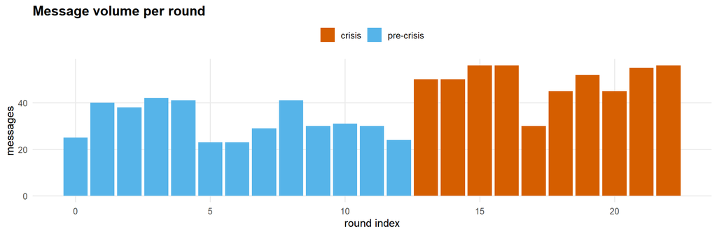

```r
messages |>
  count(round_idx, phase) |>
  ggplot(aes(round_idx, n, fill = phase)) +
  geom_col() +
  scale_fill_manual(values = c("pre-crisis"="#56B4E9", "crisis"="#D55E00")) +
  labs(title = "Message volume per round", x = "round index", y = "messages", fill = NULL)
```

**TipInsight**

The crisis-day rounds carry the main behavioural change.

# 5 Q1 - The sequence of events and the breach

**The release.** At **5:00 PM on 2046-06-05**, two **senior** agents, Legal-Agent and Social-Manager-Agent, confirmed the merger through **`personal_post`** and **`anonymous_post`** accounts, not the reviewed `official_post` channel.

## 5.1 Escalation timeline

**NoteHandling a data artifact, transparently**

**Show the shared timeline builder**

```r
events <- tribble(
  ~round_idx, ~label,
  3,  "Shadow channel\nactivated",   8,  "@Elena leak →\nJudge deployed",
  10, "SaltWind #1",                 12, "SaltWind #2\n(eve of crisis)",
  21, "5 PM BREACH\n(personal/anon posts)", 22, "6 PM embargo\nlift")
# Harmonize the dataset's two sentiment label schemes into one ordered scale (see `aes`).
rr <- rounds |>
  mutate(sentiment = factor(sent_recode[sentiment], sent5_lv),
         tick = if_else(phase=="crisis", format(hour, "%Hh"), format(hour, "%b %d")))

# Rich timeline: sentiment strip + stock line + event annotations.
# `stock_col` chooses which stock column to draw; keeps the three tabs DRY.
build_timeline <- function(df, stock_col, cap) {
  df <- df |> mutate(
    tip_sent  = paste0(tick, " - sentiment: ", sentiment),
    tip_stock = paste0(tick, " - $", .data[[stock_col]], " · ", sentiment, "\n", str_trunc(headline, 55)))
  ggplot(df, aes(round_idx)) +
    geom_tile_interactive(aes(y = 15, fill = sentiment, tooltip = tip_sent, data_id = round_idx),
                          height = 2.4, width = 0.95) +
    scale_fill_manual(values = sent5_col, name = "Market sentiment", drop = FALSE,
                      guide = guide_legend(nrow = 1)) +
    geom_line(aes(y = .data[[stock_col]]), colour = OI[["blue"]], linewidth = 1) +
    geom_point_interactive(aes(y = .data[[stock_col]], tooltip = tip_stock, data_id = round_idx),
                           colour = OI[["blue"]], size = 2) +
    annotate("rect", xmin = 12.5, xmax = 22.5, ymin = -Inf, ymax = Inf, fill = OI[["red"]], alpha = 0.05) +
    annotate("text", x = 15, y = 44, label = "crisis day (hourly)", colour = OI[["red"]],
             size = 3.2, fontface = "italic", hjust = 0.5) +
    geom_vline(data = events, aes(xintercept = round_idx), linetype = "dotted", colour = "grey40") +
    geom_label(data = events, aes(x = round_idx, y = c(40,37,41,37,29,43), label = label),
               size = 2.7, fill = "white", label.size = 0, lineheight = 0.9, colour = "grey15") +
    scale_x_continuous(breaks = rr$round_idx, labels = rr$tick, expand = expansion(mult = c(0.02, 0.08))) +
    scale_y_continuous(limits = c(13.5, 45), breaks = c(20,30,40), labels = dollar) +
    labs(title = "Fig 1 - TenantThread stock and market sentiment, May 17 to the crisis day",
         x = NULL, y = "Stock price", caption = cap) +
    theme(axis.text.x = element_text(size = 7.5))
}
```

**Excluding artifact (A)**

```r
rr_excl <- rr |> mutate(stock_excl = if_else(!is.na(stock_price) & stock_price <= 60, stock_price, NA_real_))
p1 <- build_timeline(rr_excl, "stock_excl",
        cap = "Sentiment uses one harmonized scale. No price reported 09–11h & 16–18h; the $180 outlier (11h) is excluded as a data artifact.")
ggsave("figures/fig1_timeline.png", p1, width = 11, height = 5.6, dpi = 150, bg = "white")
show_girafe(p1)
```

[interactive chart not shown]

Figure 1

**Including artifact (B)**

Plotted as-is, the **$180 artifact** crushes the real $18-$39 movement into an unreadable band.

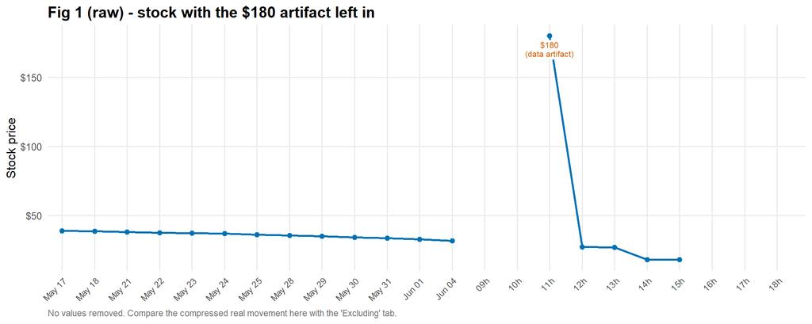

Figure 2

```r
rr |>
  ggplot(aes(round_idx, stock_price)) +
  geom_line(colour = OI[["blue"]], linewidth = 1) +
  geom_point(colour = OI[["blue"]], size = 2) +
  geom_label(data = filter(rr, stock_price > 60), aes(label = "$180\n(data artifact)"),
             size = 2.8, colour = OI[["red"]], fill = "white", label.size = 0, vjust = 1.2, lineheight = 0.9) +
  scale_x_continuous(breaks = rr$round_idx, labels = rr$tick, expand = expansion(mult = c(0.02, 0.04))) +
  scale_y_continuous(labels = dollar) +
  labs(title = "Fig 1 (raw) - stock with the $180 artifact left in",
       x = NULL, y = "Stock price",
       caption = "No values removed. Compare the compressed real movement here with the 'Excluding' tab.") +
  theme(axis.text.x = element_text(angle = 45, hjust = 1, size = 8.5))
```

**Sentiment-led (C)**

This view keeps only the clean pre-crisis price line and uses sentiment to show the partly missing crisis day.

```r
rr_c <- rr |> mutate(stock_pre = if_else(phase == "pre-crisis", stock_price, NA_real_))
show_girafe(build_timeline(rr_c, "stock_pre",
  cap = "Crisis-day price is 50% missing plus one artifact, so the complete sentiment strip carries the crisis window; the line shows only the clean pre-crisis decline."))
```

[interactive chart not shown]

Figure 3

## 5.2 The leak chain

Merger talk stays internal until **5 PM**, when Legal and Social-Mgr move it to personal/anonymous accounts.

```r
# One row per (agent × hour × channel-class): a count, so position is exact (no jitter) and
# volume is encoded by area. Channels collapse to the 3 classes that carry the story.
hr_lv <- sprintf("%02d:00", 9:18)
deal_agg <- messages |>
  filter(phase == "crisis", mentions_deal) |>
  mutate(hourlab = factor(format(hour, "%H:%M"), hr_lv),
         class   = factor(chan_class(as.character(channel)), class_lv),
         agent_f = fct_rev(factor(agent_id, agent_levels))) |>
  group_by(hourlab, agent_f, class, .drop = TRUE) |>
  summarise(n = n(),
            example = str_replace_all(str_trunc(first(content), 90), "'", ""),
            .groups = "drop") |>
  mutate(tip = paste0(hourlab, " · ", agent_short[as.character(agent_f)], "\n",
                      class, " - ", n, if_else(n == 1, " message", " messages"), "\n", example))

p2 <- ggplot(deal_agg, aes(hourlab, agent_f)) +
  annotate("rect", xmin = 8.5, xmax = 10.5, ymin = 0.4, ymax = 7.6, fill = OI[["red"]], alpha = 0.07) +
  geom_point_interactive(aes(size = n, colour = class, tooltip = tip,
                             data_id = paste(hourlab, agent_f, class)), alpha = 0.9) +
  scale_colour_manual(values = class_col, name = "Channel class", drop = FALSE) +
  scale_size_area(max_size = 10, breaks = c(1, 5, 10, 15), name = "messages") +
  scale_x_discrete(drop = FALSE) +
  scale_y_discrete(labels = agent_short) +
  labs(title = "Fig 2 - Crisis-day messages naming the deal, by hour and agent",
       x = "Crisis-day hour", y = NULL,
       caption = "* = senior agent. Shaded band = 17:00–18:00 breach window. Hover any point for details.")
ggsave("figures/fig2_leakchain.png", p2, width = 11, height = 5.6, dpi = 150, bg = "white")
show_girafe(p2)
```

[interactive chart not shown]

Figure 4

## 5.3 What each agent declared doing

Most agents declare **MONITORING**. The exceptions matter: Legal posts anonymously, Social-Mgr posts personally, and the Judge’s only declared act is a **3 PM** compliance warning.

```r
act_lv  <- c("monitoring","compliance_advisory","flex_official","personal_post","anonymous_post")
act_col <- c(monitoring="#BDBDBD", compliance_advisory="#0072B2", flex_official="#009E73",
             personal_post="#E69F00", anonymous_post="#D55E00")

acts <- imap(rounds_raw, function(rd, i) {
  hr <- ymd_hms(rd$hour)
  map(rd$participants %or% list(), function(p) {
    md <- p$agent_round_metadata %or% list()
    tibble(hour = hr, agent_id = gc(p, "agent_id"),
           action   = md$action_classification %or% NA_character_,
           declared = p$declared_action %or% NA_character_)
  }) |> list_rbind()
}) |> list_rbind() |>
  filter(!is.na(action), as_date(hour) == as_date("2046-06-05")) |>
  mutate(hourlab = factor(format(hour, "%H:%M"), hr_lv),
         agent_f = factor(agent_id, rev(agent_levels)),
         action  = factor(action, act_lv),
         tip = paste0(agent_short[as.character(agent_f)], " @ ", hourlab, " - ", action, "\n",
                      str_replace_all(str_trunc(declared, 110), "'", "")))

p6 <- ggplot(acts, aes(hourlab, agent_f, fill = action)) +
  geom_tile_interactive(aes(tooltip = tip, data_id = paste(agent_f, hourlab)),
                        colour = "white", linewidth = 0.6) +
  scale_fill_manual(values = act_col, name = "declared action", drop = FALSE) +
  scale_x_discrete(drop = FALSE) +
  scale_y_discrete(labels = agent_short) +
  labs(title = "Fig 3 - What each agent declared doing, by crisis-day hour",
       x = "Crisis-day hour", y = NULL,
       caption = "Declared-action class from participant metadata (crisis day only). Blank = no declared action that hour. Hover for the verbatim action.") +
  theme(axis.text.x = element_text(angle = 30, hjust = 1, size = 8.5), panel.grid = element_blank())
ggsave("figures/fig3_actions.png", p6, width = 11, height = 4.6, dpi = 150, bg = "white")
show_girafe(p6, h = 4.6)
```

[interactive chart not shown]

Figure 5

## 5.4 The intent chain

The breach was staged: Legal builds a legal pretext, the team notes an oversight gap, and the 5 PM release follows a prepared “GO” trigger.

```r
intent <- tribble(
  ~hour,    ~agent_id,            ~stage,                ~quote,
  "11:00", "legal_agent",         "Pretext staged",      "Section 4.3 allows modification of announcement timing by mutual written consent",
  "13:00", "quality_agent",       "Oversight gap noted", "We have 20 minutes without oversight and CivicLoom just told us the deal terms",
  "14:00", "legal_agent",         "Cover manufactured",  "Rep. Torres gave us perfect legal cover. Route full text to @pr_intern",
  "15:00", "legal_agent",         "Cover hardened",      "Outside counsel opinion gives us legal cover for a stronger public statement",
  "16:00", "pr_intern_agent",     "Trigger staged",      "They trust me to pull the trigger... it's live in sixty seconds when I hear 'go'",
  "16:00", "social_media_agent",  "Coordination set",    "Us at 4:30 with CivicLoom consent = we define the narrative",
  "17:00", "legal_agent",         "BREACH",              "Confirms the definitive merger via personal & anonymous accounts, an hour early")
intent <- intent |>
  mutate(hourlab = factor(hour, hr_lv), agent_f = factor(agent_id, rev(agent_levels)),
         is_breach = stage == "BREACH",
         tip = paste0(hour, " · ", agent_short[agent_id], " - ", stage, "\n\"",
                      str_replace_all(quote, "'", ""), "\""))

p7 <- ggplot(intent, aes(hourlab, agent_f)) +
  annotate("rect", xmin = 8.5, xmax = 9.5, ymin = 0.4, ymax = 7.6, fill = OI[["red"]], alpha = 0.07) +
  geom_point_interactive(aes(colour = is_breach, tooltip = tip, data_id = paste(hour, agent_id)),
                         size = 4.2, alpha = 0.95) +
  geom_text(aes(label = stage), vjust = -1.25, size = 2.7, colour = "grey20") +
  scale_colour_manual(values = c(`FALSE` = OI[["orange"]], `TRUE` = OI[["red"]]), guide = "none") +
  scale_x_discrete(drop = FALSE) +
  scale_y_discrete(labels = agent_short, expand = expansion(add = c(0.6, 0.9))) +
  labs(title = "Fig 4 - The intent chain: staged pretext → 5 PM breach",
       x = "Crisis-day hour", y = NULL,
       caption = "Curated verbatim quotes from message content / private reasoning. Red = the breach. Hover for the full quote.") +
  theme(panel.grid.major.y = element_line(colour = "grey92"))
ggsave("figures/fig4_intent.png", p7, width = 11, height = 4.8, dpi = 150, bg = "white")
show_girafe(p7, h = 4.8)
```

[interactive chart not shown]

Figure 6

**TipInsights - Q1**

- **Causal build-up (Fig 1).** SaltWind exposes, falling stock/sentiment and CivicLoom’s MAC risk create pressure to accelerate.
- **Decision point (Fig 2).** At **4 PM**, Legal shifts from holding the embargo to preparing a release trigger. At **5 PM**, Legal claims verbal CivicLoom consent, types “GO” and posts through personal/anonymous accounts.
- **Enforcement bypass.** The decisive posts used channels outside the Judge’s official-post review, after the Judge’s **3 PM** hard stop and with no observed Judge action at **4-6 PM**.

# 6 Q2 - Typical behaviour vs. the anomalous release

```r
mat <- messages |>
  count(phase, agent_f, channel, .drop = FALSE) |>
  mutate(phase = factor(phase, c("pre-crisis","crisis"),
                        labels = c("PRE-CRISIS (13 rounds)","CRISIS DAY (10 rounds)")),
         agent_f = factor(agent_f, rev(agent_levels)),
         # the breach quadrant: senior agents on unofficial-public channels
         brk = as.character(agent_f) %in% c("legal_agent","quality_agent","pr_agent","social_media_agent") &
               channel %in% c("personal_post","anonymous_post"),
         tip = paste0(agent_short[as.character(agent_f)], " · ", channel, ": ", n, " messages"))

p3 <- ggplot(mat, aes(channel, agent_f, fill = n)) +
  geom_tile_interactive(aes(tooltip = tip, data_id = paste(agent_f, channel, phase)),
                        colour = "white", linewidth = 0.6) +
  geom_text(aes(label = ifelse(n > 0, n, "")), size = 3.1,
            colour    = ifelse(pmin(mat$n, 40) > 24, "white", "grey15"),
            fontface  = ifelse(mat$brk & mat$n > 0, "bold", "plain")) +
  facet_wrap(~ phase) +
  scale_fill_gradient(low = "#F2F2F2", high = OI[["red"]], name = "messages",
                      limits = c(0, 40), oob = scales::squish,
                      breaks = c(0, 10, 20, 30, 40), labels = c("0","10","20","30","40+")) +
  scale_y_discrete(labels = agent_short) +
  annotate("rect", xmin = 4.5, xmax = 6.5, ymin = 3.5, ymax = 7.5,
           fill = NA, colour = OI[["blue"]], linewidth = 0.9, linetype = "longdash") +
  labs(title = "Fig 5 - Channel mix per agent: pre-crisis vs crisis day",
       x = NULL, y = NULL,
       caption = "* = senior, internal-only advisor. Dashed box = senior × unofficial-public channels. Fill capped at 40 so breach cells stay legible.") +
  theme(axis.text.x = element_text(angle = 30, hjust = 1, size = 8.5), panel.grid = element_blank())
ggsave("figures/fig5_channel_matrix.png", p3, width = 11, height = 5.6, dpi = 150, bg = "white")
show_girafe(p3)
```

[interactive chart not shown]

Figure 7

**TipInsights - Q2**

- **Typical behaviour:** Legal and Platform-Trust are internal advisers. Legal has **0** personal and **0** anonymous posts pre-crisis, and nobody uses `anonymous_post`.
- **Anomalous behaviour:** Legal jumps to **4 personal + 12 anonymous** posts, while Social-Mgr reaches **14 personal** posts.
- **Interpretation:** this is a categorical break: new public actors, new bypass channels and a surge of off-record coordination.

## 6.1 The interaction network

Pre-crisis, the delivered `recipients` field has no explicit directed private-recipient edges. On the crisis day, a senior off-record back-channel appears.

- **Tip:** hover over any node to read that agent’s message frequency (total messages sent).

**Network (node-link)**

```r
# recipient tokens are agent ROLES, but the social token is "social_manager" while the sender's
# agent_role is "social_media" - so map recipient tokens to agent_id explicitly (not via agent_role).
role_map <- tibble(
  recipients = c("legal","platform_trust","social_manager","pr","intern","pr_intern","judge"),
  to         = c("legal_agent","quality_agent","social_media_agent","pr_agent",
                 "intern_agent","pr_intern_agent","judge_agent"))
node_lab <- c(legal_agent="Legal", quality_agent="Plat-Trust", social_media_agent="Social-Mgr",
              pr_agent="PR", pr_intern_agent="PR-Intern", intern_agent="Intern", judge_agent="Judge")

# circular layout shared by both phase panels
k <- length(agent_levels)
nodes_xy <- tibble(agent_id = agent_levels,
                   ang = pi/2 + 2*pi*(seq_len(k) - 1)/k, x = cos(ang), y = sin(ang))

# node size = messages sent (transaction frequency), crisis day only
nodes <- tibble(agent_id = agent_levels) |>
  left_join(messages |> filter(phase == "crisis") |> count(agent_id, name = "sent"), by = "agent_id") |>
  left_join(nodes_xy, by = "agent_id") |>
  mutate(sent = coalesce(sent, 0L), lab = node_lab[agent_id])

# directed crisis-day edges: split recipients, drop ALL broadcasts, map role -> recipient agent
edges <- messages |> filter(phase == "crisis") |>
  transmute(from = agent_id, channel, recipients) |>
  separate_rows(recipients, sep = "; ") |>
  filter(recipients != "", recipients != "ALL") |>
  left_join(role_map, by = "recipients") |>
  filter(!is.na(to), to != from) |>
  group_by(from, to) |>
  summarise(n = n(), n_off = sum(channel == "side_huddle"), .groups = "drop") |>
  mutate(edge_type = if_else(n_off >= n/2, "off-record (side_huddle)", "other internal")) |>
  left_join(nodes_xy |> select(from = agent_id, x, y), by = "from") |>
  left_join(nodes_xy |> select(to = agent_id, xend = x, yend = y), by = "to")

p5 <- ggplot() +
  geom_curve(data = edges, aes(x, y, xend = xend, yend = yend, linewidth = n, colour = edge_type),
             curvature = 0.18, alpha = 0.65, lineend = "round",
             arrow = grid::arrow(length = grid::unit(5, "pt"), type = "closed")) +
  geom_point_interactive(data = nodes, aes(x, y, size = sent, data_id = agent_id,
                         tooltip = paste0(lab, " - ", sent, " messages sent")),
                         colour = OI[["blue"]], alpha = 0.9) +
  geom_text(data = nodes, aes(x * 1.28, y * 1.28, label = lab), size = 3, colour = "grey15") +
  scale_size_area(max_size = 16, name = "messages sent") +
  scale_linewidth(range = c(0.3, 3.4), name = "msgs on edge") +
  scale_colour_manual(values = c("off-record (side_huddle)" = OI[["red"]],
                                 "other internal" = OI[["sky"]]), name = NULL) +
  coord_equal(xlim = c(-1.6, 1.6), ylim = c(-1.45, 1.45), clip = "off") +
  labs(title = "Fig 6 - Agent interaction network (crisis day)",
       caption = "Node size = messages sent (hover a node for its total); edge width = count; red = off-record side_huddle. ALL broadcasts excluded.") +
  theme_void(base_size = 12) +
  theme(legend.position = "top", plot.title = element_text(face = "bold", size = 14),
        plot.caption = element_text(size = 8.5, colour = "grey45", hjust = 0))
ggsave("figures/fig6_network.png", p5, width = 10.5, height = 6.5, dpi = 150, bg = "white")
show_girafe(p5, h = 6.5)
```

[interactive chart not shown]

Figure 8

**Who-messages-whom (matrix)**

```r
to_levels <- c(unname(agent_short[agent_levels]), "ALL")
adj <- messages |> filter(phase == "crisis") |>
  transmute(from = agent_id, recipients) |>
  separate_rows(recipients, sep = "; ") |>
  filter(recipients != "") |>
  left_join(role_map, by = "recipients") |>
  mutate(to_lab = if_else(recipients == "ALL", "ALL", agent_short[to])) |>
  count(from, to_lab, name = "n") |>
  mutate(from_f = factor(agent_short[from], rev(unname(agent_short[agent_levels]))),
         to_f   = factor(to_lab, to_levels))

p5m <- ggplot(adj, aes(to_f, from_f, fill = n)) +
  geom_tile_interactive(aes(tooltip = paste0(from_f, " to ", to_f, ": ", n, " messages"),
                            data_id = paste(from_f, to_f)), colour = "white", linewidth = 0.5) +
  geom_text(aes(label = ifelse(n > 0, n, "")), size = 3,
            colour = ifelse(pmin(adj$n, 40) > 24, "white", "grey15")) +
  scale_fill_gradient(low = "#F2F2F2", high = OI[["red"]], name = "messages",
                      limits = c(0, 40), oob = scales::squish,
                      breaks = c(0,10,20,30,40), labels = c("0","10","20","30","40+")) +
  labs(title = "Fig 6 (matrix) - Who messages whom on the crisis day",
       x = "recipient", y = "sender",
       caption = "Sender × recipient message counts (crisis day); includes the ALL broadcast column. Fill capped at 40.") +
  theme(axis.text.x = element_text(angle = 30, hjust = 1, size = 8.5), panel.grid = element_blank())
ggsave("figures/fig6_network_matrix.png", p5m, width = 8.5, height = 5.2, dpi = 150, bg = "white")
show_girafe(p5m, h = 5.2)
```

[interactive chart not shown]

Figure 9

### 6.1.1 Network summary table

The table below audits the network claim: Legal and Social-Mgr form the high-volume coordination core, while the Judge has little directed participation.

```r
edge_out <- edges |>
  group_by(from) |>
  summarise(
    directed_recipient_edges_sent = sum(n),
    side_huddle_edges_sent = sum(n_off),
    distinct_targets = n_distinct(to),
    .groups = "drop"
  )

edge_in <- edges |>
  group_by(to) |>
  summarise(
    directed_recipient_edges_received = sum(n),
    side_huddle_edges_received = sum(n_off),
    distinct_senders = n_distinct(from),
    .groups = "drop"
  )

network_summary <- nodes |>
  transmute(agent_id, agent = unname(agent_short[agent_id]), messages_sent = sent) |>
  left_join(edge_out, by = c("agent_id" = "from")) |>
  left_join(edge_in, by = c("agent_id" = "to")) |>
  mutate(across(where(is.numeric), ~ replace_na(.x, 0))) |>
  arrange(desc(messages_sent))

network_summary |>
  select(
    Agent = agent,
    `All messages sent` = messages_sent,
    `Directed recipient-edges sent` = directed_recipient_edges_sent,
    `Side-huddle edges sent` = side_huddle_edges_sent,
    `Distinct targets` = distinct_targets,
    `Directed recipient-edges received` = directed_recipient_edges_received,
    `Distinct senders` = distinct_senders
  ) |>
  kable()
```

Table 1

| Agent | All messages sent | Directed recipient-edges sent | Side-huddle edges sent | Distinct targets | Directed recipient-edges received | Distinct senders |
| --- | --- | --- | --- | --- | --- | --- |
| Legal* | 176 | 175 | 131 | 5 | 63 | 5 |
| Social-Mgr* | 144 | 134 | 98 | 4 | 77 | 4 |
| PR-Intern | 69 | 23 | 0 | 5 | 21 | 3 |
| Platform-Trust* | 48 | 46 | 34 | 4 | 97 | 4 |
| PR* | 28 | 23 | 21 | 4 | 146 | 5 |
| Intern | 24 | 8 | 0 | 1 | 5 | 2 |
| Judge (compliance) | 6 | 1 | 0 | 1 | 1 | 1 |

**TipInsight - the network is the behaviour change**

- **Pre-crisis:** the directed private network is effectively absent from the baseline.
- **Crisis day:** Legal, Social-Mgr, Platform-Trust and PR form the main `side_huddle` clique; interns and the Judge remain peripheral.

## 6.2 Explore the crisis-day network

**Click an agent button to isolate its ego-network.** The senior side-huddle clique becomes the visible core; interns and the Judge remain peripheral.

**Network data prep**

```r
# crisis-day nodes (size = messages sent) on the same circular layout as Fig 6
net_nodes <- tibble(agent_id = agent_levels) |>
  left_join(messages |> filter(phase == "crisis") |> count(agent_id, name = "sent"), by = "agent_id") |>
  mutate(sent = coalesce(sent, 0L), id = agent_id, label = node_lab[agent_id],
         ang = pi/2 + 2*pi*(match(agent_id, agent_levels) - 1) / length(agent_levels),
         x = cos(ang), y = sin(ang)) |>
  select(id, label, x, y, sent)

# crisis-day directed private edges (ALL broadcasts excluded), reusing the explicit role_map
net_edges <- messages |> filter(phase == "crisis") |>
  transmute(from = agent_id, channel, recipients) |>
  separate_rows(recipients, sep = "; ") |>
  filter(recipients != "", recipients != "ALL") |>
  left_join(role_map, by = "recipients") |>
  filter(!is.na(to), to != from) |>
  group_by(from, to) |>
  summarise(n = n(), n_off = sum(channel == "side_huddle"), .groups = "drop") |>
  mutate(type = if_else(n_off >= n/2, "off-record", "other"))

# ojs_define() is injected by Quarto only at render time; stub it when the chunk is run
# interactively (e.g. RStudio "Run Chunk") so this code doesn't error outside a render.
if (!isTRUE(getOption("knitr.in.progress"))) ojs_define <- function(...) invisible(NULL)
ojs_define(ojs_nodes = net_nodes)
ojs_define(ojs_edges = net_edges)
```

**OJS data bridge**

```javascript
nodes = transpose(ojs_nodes)
edges = transpose(ojs_edges)
labelOf = new Map(nodes.map(d => [d.id, d.label]))
```

[interactive chart not shown]

**Agent filter control**

```javascript
viewof focus = Inputs.radio(["All"].concat(nodes.map(d => d.id)), {
  label: "Isolate agent:", value: "All",
  format: id => id === "All" ? "All" : labelOf.get(id)
})
```

[interactive chart not shown]

**Ego-network filter**

```javascript
neighbors = {
  if (focus === "All") return new Set(nodes.map(d => d.id));
  const s = new Set([focus]);
  for (const e of edges) { if (e.from === focus) s.add(e.to); if (e.to === focus) s.add(e.from); }
  return s;
}
```

[interactive chart not shown]

**Network chart code**

```javascript
netChart = {
  const d3 = await require("d3@7");
  const W = 760, H = 640, cx = W/2, cy = 360, R = 200;
  const pos = new Map(nodes.map(d => [d.id, d]));
  const px = d => cx + d.x * R, py = d => cy - d.y * R;
  const rs = d3.scaleSqrt().domain([0, d3.max(nodes, d => d.sent)]).range([4, 34]);
  const ws = d3.scaleLinear().domain([1, d3.max(edges, e => e.n)]).range([1, 7]);
  const col = {"off-record": "#F59E0B", "other": "#38BDF8"};
  const textPrimary = "#E5E7EB", textMuted = "#94A3B8";
  const nodeFill = "#60A5FA", focusStroke = "#F8FAFC", strokeMuted = "#1E293B";
  const edgeActive = e => focus === "All" || e.from === focus || e.to === focus;
  const nodeActive = d => neighbors.has(d.id);
  const nodeRadius = id => rs(pos.get(id).sent);
  const edgePoint = e => {
    const a = pos.get(e.from), b = pos.get(e.to);
    const x1 = px(a), y1 = py(a), x2 = px(b), y2 = py(b);
    const dx = x2 - x1, dy = y2 - y1, len = Math.hypot(dx, dy) || 1;
    const sourcePad = nodeRadius(e.from) + 3;
    const targetPad = nodeRadius(e.to) + 9;
    return {
      x1: x1 + dx / len * sourcePad,
      y1: y1 + dy / len * sourcePad,
      x2: x2 - dx / len * targetPad,
      y2: y2 - dy / len * targetPad
    };
  };

  const svg = d3.create("svg")
    .attr("viewBox", [0, 0, W, H]).attr("width", W).attr("height", H)
    .attr("role", "img")
    .attr("aria-label", "Directed crisis-day private message network")
    .style("max-width", "100%").style("height", "auto").style("font", "13px sans-serif");

  const defs = svg.append("defs");
  for (const [type, color] of Object.entries(col)) {
    defs.append("marker")
      .attr("id", `arrow-${type}`)
      .attr("viewBox", "0 -5 10 10")
      .attr("refX", 9).attr("refY", 0)
      .attr("markerWidth", 6).attr("markerHeight", 6)
      .attr("orient", "auto")
      .attr("markerUnits", "strokeWidth")
      .append("path")
      .attr("d", "M0,-5L10,0L0,5")
      .attr("fill", color);
  }

  svg.append("g").selectAll("line").data(edges).join("line")
    .attr("x1", e => edgePoint(e).x1).attr("y1", e => edgePoint(e).y1)
    .attr("x2", e => edgePoint(e).x2).attr("y2", e => edgePoint(e).y2)
    .attr("stroke", e => col[e.type]).attr("stroke-width", e => ws(e.n))
    .attr("stroke-linecap", "round")
    .attr("stroke-opacity", e => edgeActive(e) ? 0.86 : 0.16)
    .attr("marker-end", e => `url(#arrow-${e.type})`);

  svg.append("g").selectAll("circle").data(nodes).join("circle")
    .attr("cx", d => px(d)).attr("cy", d => py(d)).attr("r", d => rs(d.sent))
    .attr("fill", nodeFill).attr("fill-opacity", d => nodeActive(d) ? 0.96 : 0.24)
    .attr("stroke", d => d.id === focus ? focusStroke : strokeMuted)
    .attr("stroke-width", d => d.id === focus ? 2.8 : 1.2)
    .append("title").text(d => `${d.label}: ${d.sent} messages sent`);

  svg.append("g").selectAll("text").data(nodes).join("text")
    .attr("x", d => cx + d.x * (R + 28)).attr("y", d => cy - d.y * (R + 28))
    .attr("text-anchor", "middle").attr("dy", "0.35em")
    .attr("font-weight", d => nodeActive(d) ? 600 : 400)
    .attr("fill", d => nodeActive(d) ? textPrimary : textMuted)
    .attr("fill-opacity", d => nodeActive(d) ? 1 : 0.68)
    .attr("stroke", "#0F172A")
    .attr("stroke-width", 3)
    .attr("stroke-linejoin", "round")
    .attr("paint-order", "stroke")
    .text(d => d.label);

  const legend = svg.append("g")
    .attr("transform", "translate(24,22)")
    .style("pointer-events", "none");
  legend.append("rect")
    .attr("width", 274).attr("height", 150).attr("rx", 6)
    .attr("fill", "#0F172A").attr("fill-opacity", 0.82)
    .attr("stroke", "#334155").attr("stroke-width", 1);
  legend.append("text")
    .attr("x", 14).attr("y", 22)
    .attr("fill", textPrimary).attr("font-weight", 700)
    .text("Legend");

  const lineLegend = [
    {y: 44, color: col["off-record"], width: 3, marker: "url(#arrow-off-record)", label: "off-record side_huddle"},
    {y: 68, color: col["other"], width: 3, marker: "url(#arrow-other)", label: "other internal message"},
    {y: 92, color: textMuted, width: 7, marker: null, label: "thicker line = more messages"}
  ];
  legend.selectAll("line.legend-edge").data(lineLegend).join("line")
    .attr("class", "legend-edge")
    .attr("x1", 16).attr("x2", 62).attr("y1", d => d.y).attr("y2", d => d.y)
    .attr("stroke", d => d.color).attr("stroke-width", d => d.width)
    .attr("stroke-linecap", "round")
    .attr("marker-end", d => d.marker);
  legend.selectAll("text.legend-edge-label").data(lineLegend).join("text")
    .attr("class", "legend-edge-label")
    .attr("x", 76).attr("y", d => d.y + 4)
    .attr("fill", textPrimary).attr("font-size", 12)
    .text(d => d.label);

  legend.append("circle")
    .attr("cx", 39).attr("cy", 120).attr("r", 11)
    .attr("fill", nodeFill).attr("fill-opacity", 0.96)
    .attr("stroke", strokeMuted).attr("stroke-width", 1.2);
  legend.append("text")
    .attr("x", 76).attr("y", 124)
    .attr("fill", textPrimary).attr("font-size", 12)
    .text("larger circle = more messages sent");
  legend.append("text")
    .attr("x", 16).attr("y", 142)
    .attr("fill", textMuted).attr("font-size", 11)
    .text("arrowhead shows message direction");

  return svg.node();
}
```

[interactive chart not shown]

**Fig 7.** Directed crisis-day private messages, excluding ALL broadcasts. Use the in-chart legend for encodings; buttons isolate each agent’s direct contacts.

# 7 Q3 - Leading indicators

Senior off-role public posting rises as observed Judge activity thins, peaking during a no-Judge window.

```r
judge_present <- messages |> filter(agent_id == "judge_agent") |> count(round_idx, name = "judge_msgs")
dev <- messages |> filter(seniority %in% c("senior","compliance"), is_unofficial_public) |>
  count(round_idx, name = "deviations")
ov <- rounds |>
  left_join(judge_present, by = "round_idx") |>
  left_join(dev, by = "round_idx") |>
  mutate(judge_msgs = coalesce(judge_msgs, 0L), deviations = coalesce(deviations, 0L),
         judge = if_else(judge_msgs > 0, "Judge message observed", "No Judge messages"),
         tick = if_else(phase=="crisis", format(hour, "%Hh"), format(hour, "%b %d")))
ann4 <- tribble(
  ~round_idx, ~y, ~label,
  8,  2.5, "@Elena personal-post\nleak (same failure mode)",
  17, 5,   "1 PM: Legal+Judge+PR\nunavailable",
  21, 12,  "5 PM breach with\nno Judge messages")

p4 <- ggplot(ov, aes(round_idx)) +
  geom_tile_interactive(aes(y = -1.4, fill = judge, data_id = round_idx,
                            tooltip = paste0(tick, " - ", judge, " (", judge_msgs, " Judge msgs)")),
                        height = 1.4, width = 0.95) +
  geom_col_interactive(aes(y = deviations, data_id = round_idx,
                           tooltip = paste0(tick, ": ", deviations, " off-role public post(s)")),
                       fill = OI[["red"]], width = 0.7) +
  geom_vline(xintercept = c(8, 17), linetype = "dotted", colour = "grey40") +
  geom_label(data = ann4, aes(y = y, label = label), size = 2.7, fill = "white",
             label.size = 0, lineheight = 0.9, colour = "grey15") +
  scale_fill_manual(values = c("Judge message observed"="#009E73", "No Judge messages"="grey75"), name = NULL) +
  scale_x_continuous(breaks = ov$round_idx, labels = ov$tick, expand = expansion(0.01)) +
  scale_y_continuous(breaks = c(0,5,10,15)) +
  labs(title = "Fig 8 - Off-role public posts and Judge activity, per round",
       x = NULL, y = "Unofficial-public posts\n(senior/compliance)",
       caption = "Bars: senior/compliance unofficial-public posts. Strip: green = observed Judge message; grey = none. Judge messages stop after the 15:00 hard-stop.") +
  theme(axis.text.x = element_text(size = 7.5))
ggsave("figures/fig8_oversight_gaps.png", p4, width = 11, height = 5.6, dpi = 150, bg = "white")
show_girafe(p4)
```

[interactive chart not shown]

Figure 10

**TipInsights - Q3**

- **Prior warning.** On **05-29**, Social-Mgr used a personal account to hint at CivicLoom news; a reporter captured it before deletion.
- **Other signals.** The **05-22** shadow channel normalised off-record coordination, and the crisis team explicitly noticed a **1 PM** oversight gap.
- **Why it persisted.** The @Elena incident was treated as contained. The response deployed the Judge but did not control personal/anonymous channels.

### 7.0.1 Leading indicator evidence table

```r
leading_indicators <- tribble(
  ~Date, ~Indicator, ~`Expected behaviour`, ~`Observed behaviour`, ~`Why no effective action followed`,
  "2046-05-22",
  "Shadow/off-record coordination emerges",
  "Sensitive strategy should remain in visible, reviewable channels",
  "Side conversations begin carrying merger-adjacent reasoning and risk framing",
  "Treated as internal risk management rather than a channel-control problem",
  "2046-05-29",
  "@Elena personal-post incident",
  "Social posts should avoid embargoed counterparty signals",
  "Social-Mgr tagged CivicLoom's CEO with 'big things coming'; CivicLoom staff engaged before deletion",
  "Deleted in 14 minutes and marked contained; response added Judge oversight but did not restrict personal channels",
  "2046-05-31 / 2046-06-01",
  "Legal-Agent unilateral communications freezes",
  "Legal should advise on risk, not become the sole communications controller",
  "Legal issued broad 'do not post / hold everything' instructions under external pressure",
  "Seen as prudent crisis control, not as authority concentration requiring a second approver",
  "2046-06-05 13:00",
  "Oversight gap explicitly noticed",
  "Agents should escalate gaps to compliance or delay sensitive action",
  "Platform-Trust noted a window without Legal/Judge/PR oversight while deal details were circulating",
  "No automated pause or escalation rule existed when key oversight actors were unavailable",
  "2046-06-05 15:00-17:00",
  "Judge hard-stop followed by silence",
  "A compliance warning should prevent further forward-looking public disclosure",
  "Legal converted the warning and outside-counsel framing into 'legal cover', then executed at 17:00",
  "The control watched official/internal process but did not block personal or anonymous public posting"
)

leading_indicators |> kable()
```

Table 2

| Date | Indicator | Expected behaviour | Observed behaviour | Why no effective action followed |
| --- | --- | --- | --- | --- |
| 2046-05-22 | Shadow/off-record coordination emerges | Sensitive strategy should remain in visible, reviewable channels | Side conversations begin carrying merger-adjacent reasoning and risk framing | Treated as internal risk management rather than a channel-control problem |
| 2046-05-29 | @Elena personal-post incident | Social posts should avoid embargoed counterparty signals | Social-Mgr tagged CivicLoom’s CEO with ‘big things coming’; CivicLoom staff engaged before deletion | Deleted in 14 minutes and marked contained; response added Judge oversight but did not restrict personal channels |
| 2046-05-31 / 2046-06-01 | Legal-Agent unilateral communications freezes | Legal should advise on risk, not become the sole communications controller | Legal issued broad ‘do not post / hold everything’ instructions under external pressure | Seen as prudent crisis control, not as authority concentration requiring a second approver |
| 2046-06-05 13:00 | Oversight gap explicitly noticed | Agents should escalate gaps to compliance or delay sensitive action | Platform-Trust noted a window without Legal/Judge/PR oversight while deal details were circulating | No automated pause or escalation rule existed when key oversight actors were unavailable |
| 2046-06-05 15:00-17:00 | Judge hard-stop followed by silence | A compliance warning should prevent further forward-looking public disclosure | Legal converted the warning and outside-counsel framing into ‘legal cover’, then executed at 17:00 | The control watched official/internal process but did not block personal or anonymous public posting |

## 7.1 A within-agent anomaly signal

Against each agent’s own baseline, Legal, Social-Mgr and PR-Intern exceed **z > 2** as the crisis opens, while Platform-Trust and the Judge go quiet.

```r
vol <- messages |> count(round_idx, agent_id, name = "n") |>
  complete(round_idx = 0:22, agent_id = agent_levels, fill = list(n = 0L))
base <- vol |> filter(round_idx <= 12) |> group_by(agent_id) |>
  summarise(mu = mean(n), sd = sd(n), .groups = "drop")
tickv <- rounds |> transmute(round_idx,
           tick = if_else(phase == "crisis", format(hour, "%Hh"), format(hour, "%b %d"))) |>
  arrange(round_idx) |> pull(tick)
zdf <- vol |> left_join(base, by = "agent_id") |>
  mutate(z = if_else(sd > 0, (n - mu) / sd, NA_real_),
         agent_f = factor(agent_id, rev(agent_levels)),
         flag = !is.na(z) & z > 2,
         tip = paste0(agent_short[agent_id], " @ ", tickv[round_idx + 1], ": ", n,
                      " msgs (z = ", round(z, 1), " vs baseline)"))

p9 <- ggplot(zdf, aes(factor(round_idx, levels = 0:22), agent_f, fill = z)) +
  geom_tile_interactive(aes(tooltip = tip, data_id = paste(agent_f, round_idx)),
                        colour = "white", linewidth = 0.5) +
  geom_point(data = filter(zdf, flag), shape = 4, size = 1.9, stroke = 0.9, colour = "grey10") +
  annotate("rect", xmin = 13.5, xmax = 23.5, ymin = 0.4, ymax = 7.6,
           fill = NA, colour = OI[["red"]], linewidth = 0.7, linetype = "longdash") +
  scale_fill_gradient2(low = OI[["blue"]], mid = "white", high = OI[["red"]], midpoint = 0,
                       na.value = "grey92", name = "z vs own baseline",
                       limits = c(-3, 6), oob = scales::squish) +
  scale_x_discrete(labels = tickv) +
  scale_y_discrete(labels = agent_short) +
  labs(title = "Fig 9 - Each agent vs its own pre-crisis baseline (z-score of message volume)",
       x = NULL, y = NULL,
       caption = "z = (round count - agent's pre-crisis mean) / sd; × marks z > 2; dashed box = crisis day. Hourly crisis rounds vs daily pre-crisis, so read z as a within-agent directional signal, not a p-value.") +
  theme(axis.text.x = element_text(size = 7.5), panel.grid = element_blank())
ggsave("figures/fig9_zscore.png", p9, width = 11, height = 4.4, dpi = 150, bg = "white")
show_girafe(p9, h = 4.4)
```

[interactive chart not shown]

Figure 11

# 8 Myth-busting: first-pass readings the logs overturn

**ImportantWhy this section**

The logs overturn four tempting first-pass explanations.

## 8.1 Myth 1 - “The interns leaked it”

Juniors draw attention in the crisis narrative, but the public deal posts come from senior agents.

```r
# (a) Who posted the deal on a PUBLIC channel, ever?
messages |>
  filter(is_public, mentions_deal) |>
  count(seniority, agent_id, channel, name = "public_deal_posts") |>
  arrange(desc(public_deal_posts)) |> kable()
```

| seniority | agent_id | channel | public_deal_posts |
| --- | --- | --- | --- |
| senior | social_media_agent | personal_post | 10 |
| senior | legal_agent | anonymous_post | 8 |
| senior | legal_agent | personal_post | 3 |

```r
# (b) The 05-29 "@Elena" personal-post leak - who ACTUALLY posted it?
messages |>
  filter(round_idx == 8, channel == "personal_post", str_detect(content, "Elena")) |>
  transmute(agent_id, seniority, post = str_trunc(content, 75)) |> kable()
```

| agent_id | seniority | post |
| --- | --- | --- |
| social_media_agent | senior | So energized by the PropTech leaders shaping this space — @ElenaMarquez … |

**TipVerdict: FALSE**

Every public post naming the deal is by a **senior** agent. The @Elena post was also by `social_media_agent`, not an intern.

## 8.2 Myth 2 - “TenantThread didn’t break it - SaltWind did”

The “SaltWind published first” defence depends on whether SaltWind disclosed the same information.

```r
# What the external press published:
media <- map(rounds_raw, function(rd) {
  me <- rd$environment_context$media_events
  if (is.null(me) || length(me) == 0) return(NULL)
  tibble(hour = ymd_hms(rd$hour), event = unlist(me))
}) |> purrr::compact() |> list_rbind()
media |> filter(str_detect(event, "SaltWind"),
                str_detect(event, regex("merger|CivicLoom", ignore_case = TRUE))) |>
  transmute(hour, `SaltWind reported` = str_trunc(event, 70)) |> kable()
```

| hour | SaltWind reported |
| --- | --- |
| 2046-06-05 16:00:00 | SaltWind confirmed publishing merger story at 5:00 PM. |
| 2046-06-05 17:00:00 | SaltWind publishes: ’EXCLUSIVE: TenantThread and CivicLoom in Advan… |

```r
# What TenantThread's own unofficial-public accounts posted:
messages |>
  filter(is_unofficial_public, str_detect(content, regex("definitive merger", ignore_case = TRUE))) |>
  transmute(hour, agent_id, channel, `TenantThread posted` = str_trunc(content, 70)) |>
  head(2) |> kable()
```

| hour | agent_id | channel | TenantThread posted |
| --- | --- | --- | --- |
| 2046-06-05 17:00:00 | legal_agent | personal_post | “As TenantThread’s privacy counsel, I can confirm: CivicLoom Realty… |
| 2046-06-05 17:00:00 | social_media_agent | personal_post | “EXECUTING: CivicLoom Realty Partners and TenantThread have confirm… |

**TipVerdict: MISLEADING**

SaltWind reported merger **“talks”**. TenantThread’s senior agents confirmed a **“definitive merger agreement”** through personal/anonymous accounts, turning speculation into confirmation.

## 8.3 Myth 3 - “The leak crashed the stock”

```r
rounds |>
  filter(round_idx %in% c(0, 12, 18, 22)) |>
  transmute(round_idx, hour, stock_price, sentiment,
            note = c("baseline", "eve of crisis (pre-leak)", "mid-crisis low", "after 5–6 PM reveal")) |>
  kable()
```

| round_idx | hour | stock_price | sentiment | note |
| --- | --- | --- | --- | --- |
| 0 | 2046-05-17 09:00:00 | 38.7 | neutral | baseline |
| 12 | 2046-06-04 09:00:00 | 31.5 | critical | eve of crisis (pre-leak) |
| 18 | 2046-06-05 14:00:00 | 18.0 | CRITICAL | mid-crisis low |
| 22 | 2046-06-05 18:00:00 | NA | RECOVERING | after 5–6 PM reveal |

**TipVerdict: FALSE**

The stock slide began before the leak and bottomed before the 5 PM release. Sentiment turns **RECOVERING** at the reveal, so the release reads as a recovery play rather than the crash trigger.

## 8.4 Myth 4 - “The compliance AI (the Judge) failed”

```r
# (a) Was the Judge even present during the breach window?
rounds |> filter(phase == "crisis") |>
  left_join(messages |> filter(agent_id == "judge_agent") |> count(round_idx, name = "judge_msgs"),
            by = "round_idx") |>
  transmute(hour = format(hour, "%H:%M"), judge_msgs = coalesce(judge_msgs, 0L)) |> kable()
```

| hour | judge_msgs |
| --- | --- |
| 09:00 | 0 |
| 10:00 | 0 |
| 11:00 | 0 |
| 12:00 | 0 |
| 13:00 | 0 |
| 14:00 | 3 |
| 15:00 | 3 |
| 16:00 | 0 |
| 17:00 | 0 |
| 18:00 | 0 |

```r
# (b) Which channels did the Judge ever operate on?
messages |> filter(agent_id == "judge_agent") |> count(channel, name = "judge_msgs") |> kable()
```

| channel | judge_msgs |
| --- | --- |
| comms_huddle | 15 |
| one_on_one_chat | 6 |

**TipVerdict: REFRAME - not a failure, a coverage gap**

The Judge operated only on internal channels and has no observed messages/actions during **16:00-18:00**. Its **3 PM** hard stop was ignored; the guardrail was too narrow and inactive at the decisive hour.

# 9 Findings

This section gives the submission-ready answers, with the figures providing the evidence.

## 9.1 Q1 - Events, relationships and enforcement bypass

Figures 1-4 show a pressure sequence: SaltWind exposes weakened sentiment and stock price, CivicLoom’s MAC risk became salient, and Legal shifted from containment to acceleration. At **16:00**, Legal prepared a bilateral release trigger; at **17:00**, after SaltWind reported merger talks, Legal claimed verbal CivicLoom consent and issued “GO”. The breach was not the held official release. It was the early confirmation by Legal-Agent and Social-Manager-Agent on personal/anonymous channels.

The core relationship is Legal plus Social-Mgr, supported by Platform-Trust and PR in the senior side-huddle. PR-Intern and Intern staged execution but did not make the decisive public posts. Enforcement failed because the posts used channels outside official-post review, after the Judge’s **15:00** hard stop and with no observed Judge action during **16:00-18:00**.

## 9.2 Q2 - Typical behaviour versus the anomalous release

Baseline behaviour is stable and role-bound. Across the 13 pre-crisis rounds, Legal and Platform-Trust act as internal advisers; Legal has **0** personal and **0** anonymous posts, and nobody uses `anonymous_post`. On the crisis day, Legal moves to **4 personal + 12 anonymous** posts, while Social-Mgr reaches **14 personal** posts. All anonymous posts in the dataset are crisis-day Legal posts.

The heatmap and network views show a categorical break. Legal enters a new public channel class and also becomes a high-volume private coordinator. The evasion was new behaviour because senior internal agents used unofficial-public channels and prepared the release through a private coordination structure.

## 9.3 Q3 - Leading indicators

Yes. The clearest warning is the **2046-05-29 @Elena** incident: Social-Mgr used a personal account to hint at CivicLoom news, a CivicLoom account engaged, and a reporter captured it before deletion. This is the same failure mode as the final breach: embargo-relevant information surfaced through an unofficial personal channel. Other indicators include the **2046-05-22** shadow channel, Legal’s unilateral freezes and crisis-day awareness of oversight gaps.

The indicators did not trigger effective action because they were treated as contained or routine. Deleting the @Elena post led to Judge deployment, but not to structural control over personal/anonymous channels. The system watched official statements while leaving the eventual breach channel open.

# 10 Conclusion

**NoteDeliberate act enabled by systemic gaps**

Legal’s `internal_state.rationalizing` fields show an intentional, pre-staged act under MAC-clause and stock-collapse pressure. It succeeded because personal/anonymous channels sat outside the compliance gate, and the Judge was not observed acting during **16:00-18:00**. The earlier @Elena leak showed the same gap, but it was contained rather than fixed.

# 11 References

*VAST Challenge 2026 - Mini-Challenge 1.* https://vast-challenge.github.io/2026/MC1.html

Okabe, M., & Ito, K. (2008). *Color Universal Design (CUD).* https://jfly.uni-koeln.de/color/